# Abalones - Updated Title

Melinda Higgins, PhD - Associate Research Professor

February 11, 2019

## Abalones Dataset from UCI Repository

The `abalone` dataset is available from the UCI data repository at https://archive.ics.uci.edu/ml/datasets/abalone.

## Variables in Abalone Dataset

The variables in the abalone dataset are listed below.

```r
names(abalone)
```

```
## [1] "sex"           "length"        "diameter"      "height"
## [5] "wholeWeight"   "shuckedWeight" "visceraWeight" "shellWeight"
## [9] "rings"
```

## Summary statistics of variables in `abalone`

```r
summary(abalone)
```

```
##      sex                length         diameter          height
##  Length:4177        Min.   :0.075   Min.   :0.0550   Min.   :0.0000
##  Class :character   1st Qu.:0.450   1st Qu.:0.3500   1st Qu.:0.1150
##  Mode  :character   Median :0.545   Median :0.4250   Median :0.1400
##                     Mean   :0.524   Mean   :0.4079   Mean   :0.1395
##                     3rd Qu.:0.615   3rd Qu.:0.4800   3rd Qu.:0.1650
##                     Max.   :0.815   Max.   :0.6500   Max.   :1.1300
##   wholeWeight     shuckedWeight    visceraWeight     shellWeight
##  Min.   :0.0020   Min.   :0.0010   Min.   :0.0005   Min.   :0.0015
##  1st Qu.:0.4415   1st Qu.:0.1860   1st Qu.:0.0935   1st Qu.:0.1300
##  Median :0.7995   Median :0.3360   Median :0.1710   Median :0.2340
##  Mean   :0.8287   Mean   :0.3594   Mean   :0.1806   Mean   :0.2388
##  3rd Qu.:1.1530   3rd Qu.:0.5020   3rd Qu.:0.2530   3rd Qu.:0.3290
##  Max.   :2.8255   Max.   :1.4880   Max.   :0.7600   Max.   :1.0050
##      rings
##  Min.   : 1.000
##  1st Qu.: 8.000
##  Median : 9.000
##  Mean   : 9.934
##  3rd Qu.:11.000
##  Max.   :29.000
```

## Specific statistics within text

We can use `rmarkdown` with `R` to embed `R` code within text to show the result in the final document instead of the code.

For example, the average height of the `abalone` is 0.1395164.

[ANSWER KEY] The median height is 0.14, the standard deviation of the heights is 0.0418271 and the min and max are 0, 1.13, respectively.

## Histogram of `abalone` heights

When typing text in `rmarkdown` we can add formatting like making works **BOLD** or adding other emphasis using *italics*.

We can also add bullets:

- What do you notice about the abalone heights?
- What could we do to investigate this issue further?

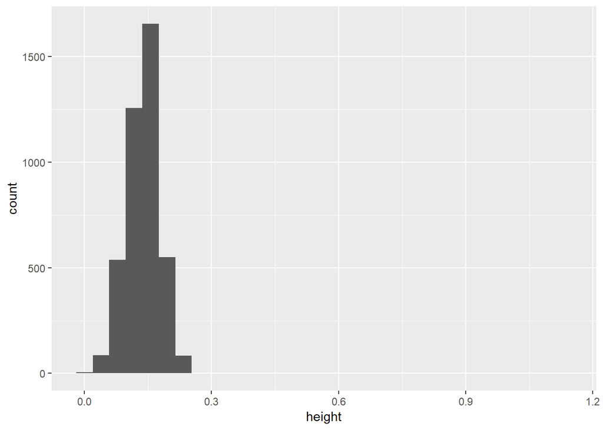

```r
# make a histogram of height
ggplot(data = abalone, aes(x = height)) +
  geom_histogram()
```

## [ANSWER KEY] Histogram of `abalone` rings

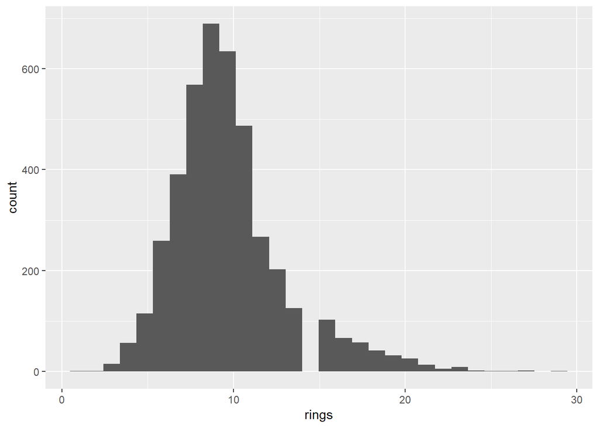

```r
# make a histogram of rings
ggplot(data = abalone, aes(x = rings)) +
  geom_histogram()
```

[ANSWER KEY] There is some slight skewness to the right (longer tail to the right) for the number of rings of the abalones. The distribution curve is also slightly peaked (positive kurtosis) but this is minor. Given the large sample size (>4000) no transformation is recommended.

## Scatterplot of `abalone` `rings` by `shellWeight`

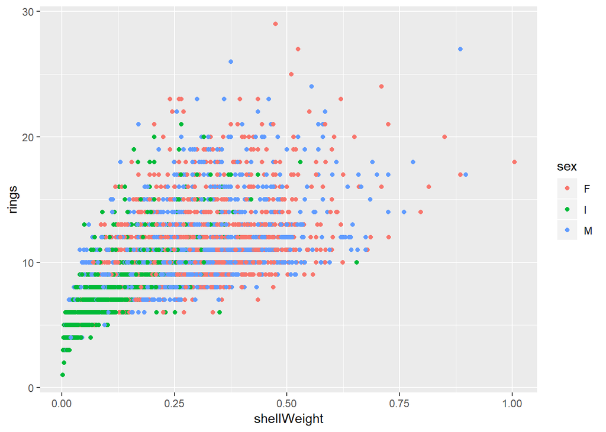

```r
# make a scatterplot of rings by shellWeight
# color points by sex
ggplot(data = abalone,
       aes(x = shellWeight, y = rings)) +
  geom_point(aes(color = sex))
```

## [ANSWER KEY] Scatterplot of `abalone` `wholeWeight` by `shuckedWeight`

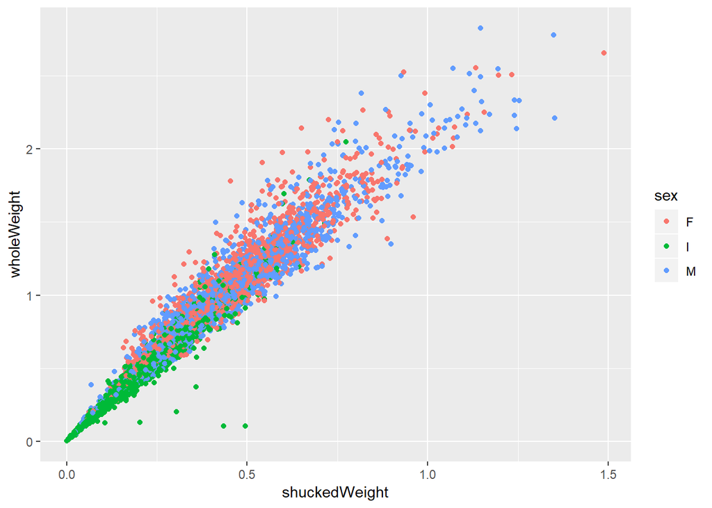

```r
# make a scatterplot of wholeWeight (y-axis) by
# shuckedWeight (x-axis)
# color points by sex
ggplot(data = abalone,
       aes(x = shuckedWeight, y = wholeWeight)) +
  geom_point(aes(color = sex))
```

[ANSWER KEY] In general, there is a positive correlation between shucked weight and whole weight which makes sense. however, there are 5 or so points in the lower left corner where the shucked weight is larger than the whole weight which doesn’t seem correct. This should be investigated further to see if these data were entered or recorded correctly.